# Estudio estadístico sobre teleorientación psicológica dirigido a usuarios de Óyeme mayores de 18 años que requieran atención para la salud mental debido a la pandemia atravesada

### Pruebas de Hipótesis

```r
colorArea <- function(from, to, density, ..., col="blue", dens=NULL){
y_seq <- seq(from, to, length.out=500)
d <- c(0, density(y_seq, ...), 0)
polygon(c(from, y_seq, to), d, col=col, density=dens)
}
```

#### Cantidad de situaciones de estrés

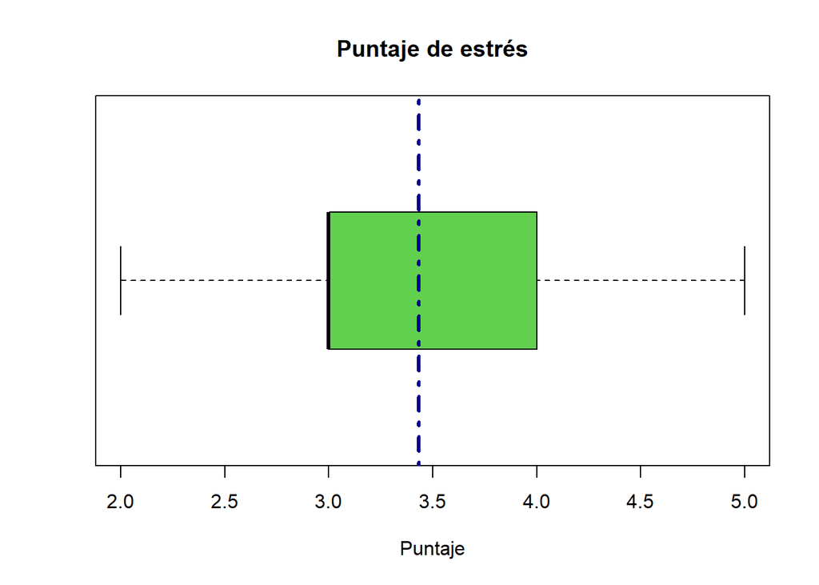

La variable **Situaciones** representa un puntaje entre 1 a 5 de situaciones de estrés durante la semana de los encuestados, el rango de esta variable no es amplio, el cual es de 2 a 5, por lo que consideramos que la data es no es tan variable a comparación de los demás. Asimismo, el gráfico de boxplot que se muestra nos sirve para poder visualizar el rango completo de la data de manera ordenada. Finalmente, la media muestral es 3.43 de estrés.

##### HIPÓTESIS I

Ho = La mayor cantidad de situaciones de estrés presentadas por nuestros usuarios son en promedio **mayores o iguales** a 3

$H_{0}:µ >= 3$

H1 =La mayor cantidad de situaciones de estrés presentadas por nuestros usuarios son en promedio **menores** a 3

$H_{1}:µ < 3$

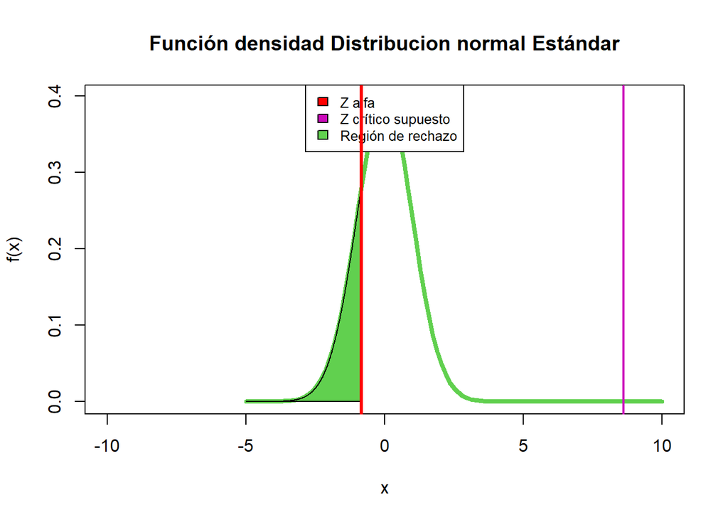

##### Intervalo de confianza para la hipótesis 1

Intervalo de confianza: [3.36, 5]

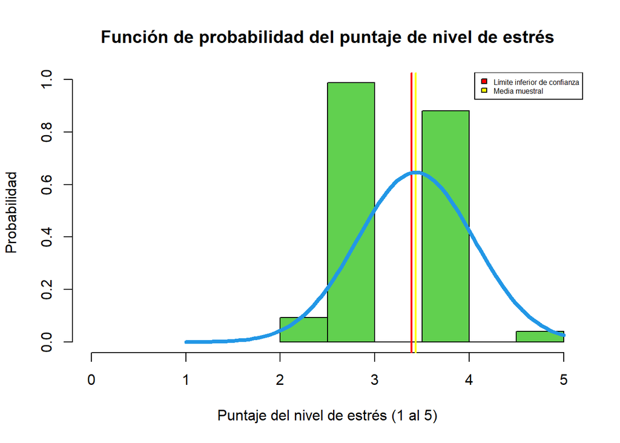

```r
hist(data1, prob=T, ylab="Probabilidad", xlab="Puntaje del nivel de estrés (1 al 5)", main="Función de probabilidad del puntaje de nivel de estrés", col=3, xlim=c(0,5))
abline(v=10, col=6, lwd=2) #930
abline(v=med, col="yellow", lwd=2)
xIC=med+(z1*(sd/sqrt(n)))
abline(v=xIC, col="red", lwd=2)
curve(dnorm(x,mean(data1, na.rm=TRUE),sd(data1, na.rm=TRUE)), from=1, to=5, xlim=c(1, 5), col=4, lwd=4, add=T)
legend("topright",legend=c("Límite inferior de confianza","Media muestral"), cex = 0.5, fill = c("red","yellow"))
```